# Zadanie 1: Analyza morfologie antarktickych tucniakov (EDA)

Jozef Barčák

2026-09-30

Cielom je preskumat telesne proporcie tucniakov z datasetu palmerpenguins, najst rozdiely medzi podskupinami (druh, pohlavie) a overit vztahy medzi meranymi velicinami.

```r
# install.packages("palmerpenguins")
library(palmerpenguins)
library(mice)
library(psych)
library(moments)
library(DescTools)
```

# 1. Zakladny pohlad na data

Dataset ma 344 tucniakov a 8 premennych. Kategoricke (factor) su species, island a sex, ciselne su bill_length_mm, bill_depth_mm, flipper_length_mm, body_mass_g a rok merania (year).

```r
str(penguins)
```

```
## tibble [344 × 8] (S3: tbl_df/tbl/data.frame)
##  $ species          : Factor w/ 3 levels "Adelie","Chinstrap",..: 1 1 1 1 1 1 1 1 1 1 ...
##  $ island           : Factor w/ 3 levels "Biscoe","Dream",..: 3 3 3 3 3 3 3 3 3 3 ...
##  $ bill_length_mm   : num [1:344] 39.1 39.5 40.3 NA 36.7 39.3 38.9 39.2 34.1 42 ...
##  $ bill_depth_mm    : num [1:344] 18.7 17.4 18 NA 19.3 20.6 17.8 19.6 18.1 20.2 ...
##  $ flipper_length_mm: int [1:344] 181 186 195 NA 193 190 181 195 193 190 ...
##  $ body_mass_g      : int [1:344] 3750 3800 3250 NA 3450 3650 3625 4675 3475 4250 ...
##  $ sex              : Factor w/ 2 levels "female","male": 2 1 1 NA 1 2 1 2 NA NA ...
##  $ year             : int [1:344] 2007 2007 2007 2007 2007 2007 2007 2007 2007 2007 ...
```

```r
summary(penguins)
```

```
##       species          island    bill_length_mm  bill_depth_mm
##  Adelie   :152   Biscoe   :168   Min.   :32.10   Min.   :13.10
##  Chinstrap: 68   Dream    :124   1st Qu.:39.23   1st Qu.:15.60
##  Gentoo   :124   Torgersen: 52   Median :44.45   Median :17.30
##                                  Mean   :43.92   Mean   :17.15
##                                  3rd Qu.:48.50   3rd Qu.:18.70
##                                  Max.   :59.60   Max.   :21.50
##                                  NAs    :2       NAs    :2
##  flipper_length_mm  body_mass_g       sex           year
##  Min.   :172.0     Min.   :2700   female:165   Min.   :2007
##  1st Qu.:190.0     1st Qu.:3550   male  :168   1st Qu.:2007
##  Median :197.0     Median :4050   NAs   : 11   Median :2008
##  Mean   :200.9     Mean   :4202                Mean   :2008
##  3rd Qu.:213.0     3rd Qu.:4750                3rd Qu.:2009
##  Max.   :231.0     Max.   :6300                Max.   :2009
##  NAs    :2         NAs    :2
```

# 2. Chybajuce data

```r
sum(is.na(penguins$sex))
```

```
## [1] 11
```

```r
sum(is.na(penguins$bill_length_mm))
```

```
## [1] 2
```

```r
sum(is.na(penguins$body_mass_g))
```

```
## [1] 2
```

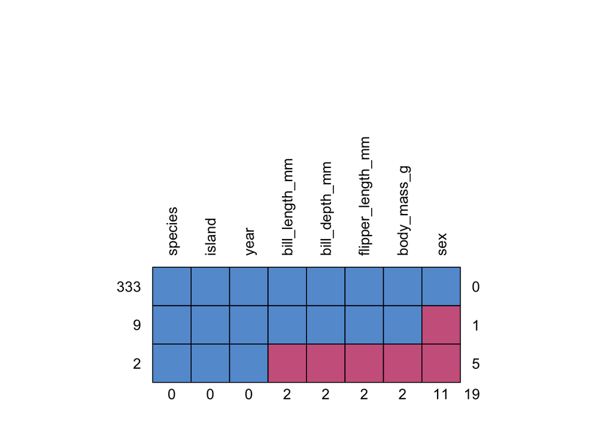

```
##     species island year bill_length_mm bill_depth_mm flipper_length_mm
## 333       1      1    1              1             1                 1
## 9         1      1    1              1             1                 1
## 2         1      1    1              0             0                 0
##           0      0    0              2             2                 2
##     body_mass_g sex
## 333           1   1  0
## 9             1   0  1
## 2             0   0  5
##               2  11 19
```

```r
md.pattern(penguins, rotate.names = TRUE)
```

Pohlavie chyba u 11 tucniakov, ciselne miery u 2. Prislusne riadky vynechame a pracujeme s uplnym datasetom.

```r
tucniaky <- na.omit(penguins)
str(tucniaky)
```

```
## tibble [333 × 8] (S3: tbl_df/tbl/data.frame)
##  $ species          : Factor w/ 3 levels "Adelie","Chinstrap",..: 1 1 1 1 1 1 1 1 1 1 ...
##  $ island           : Factor w/ 3 levels "Biscoe","Dream",..: 3 3 3 3 3 3 3 3 3 3 ...
##  $ bill_length_mm   : num [1:333] 39.1 39.5 40.3 36.7 39.3 38.9 39.2 41.1 38.6 34.6 ...
##  $ bill_depth_mm    : num [1:333] 18.7 17.4 18 19.3 20.6 17.8 19.6 17.6 21.2 21.1 ...
##  $ flipper_length_mm: int [1:333] 181 186 195 193 190 181 195 182 191 198 ...
##  $ body_mass_g      : int [1:333] 3750 3800 3250 3450 3650 3625 4675 3200 3800 4400 ...
##  $ sex              : Factor w/ 2 levels "female","male": 2 1 1 1 2 1 2 1 2 2 ...
##  $ year             : int [1:333] 2007 2007 2007 2007 2007 2007 2007 2007 2007 2007 ...
##  - attr(*, "na.action")= 'omit' Named int [1:11] 4 9 10 11 12 48 179 219 257 269 ...
##   ..- attr(*, "names")= chr [1:11] "4" "9" "10" "11" ...
```

Ostalo 333 tucniakov.

# 3. Pocetnosti v skupinach

```r
table(tucniaky$species)
```

```
##
##    Adelie Chinstrap    Gentoo
##       146        68       119
```

```r
prop.table(table(tucniaky$species))
```

```
##
##    Adelie Chinstrap    Gentoo
## 0.4384384 0.2042042 0.3573574
```

```r
table(tucniaky$island)
```

```
##
##    Biscoe     Dream Torgersen
##       163       123        47
```

```r
table(tucniaky$sex)
```

```
##
## female   male
##    165    168
```

```r
table(tucniaky$species, tucniaky$island)
```

```
##
##             Biscoe Dream Torgersen
##   Adelie        44    55        47
##   Chinstrap      0    68         0
##   Gentoo       119     0         0
```

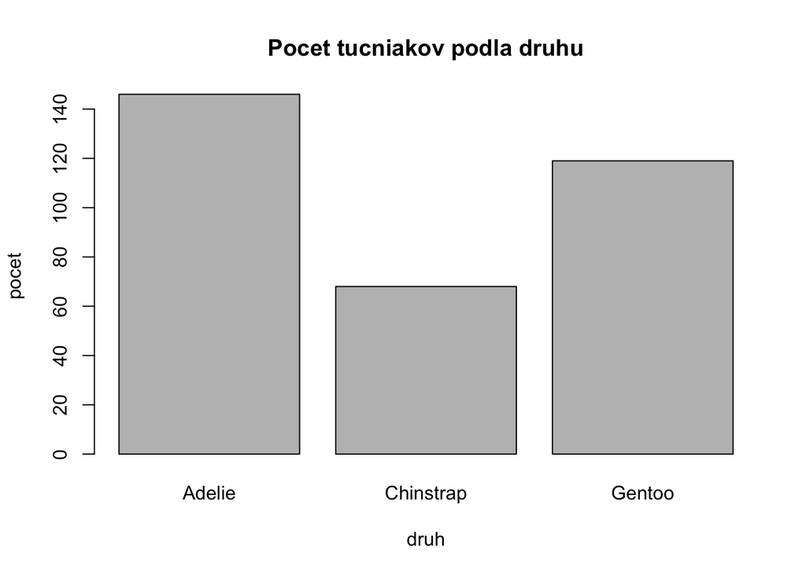

```r
plot(tucniaky$species, main = "Pocet tucniakov podla druhu",
     xlab = "druh", ylab = "pocet")
```

Adelie je 146, Gentoo 119, Chinstrap 68. Samcov a samic je skoro rovnako (168 a 165). Gentoo zije len na ostrove Biscoe, Chinstrap len na Dream, Adelie na vsetkych troch.

# 4. Charakteristiky ciselnych premennych

```r
describe(tucniaky[, c("bill_length_mm", "bill_depth_mm",
                      "flipper_length_mm", "body_mass_g")])
```

```
##                   vars   n    mean     sd median trimmed    mad    min    max
## bill_length_mm       1 333   43.99   5.47   44.5   43.98   6.97   32.1   59.6
## bill_depth_mm        2 333   17.16   1.97   17.3   17.19   2.22   13.1   21.5
## flipper_length_mm    3 333  200.97  14.02  197.0  200.36  16.31  172.0  231.0
## body_mass_g          4 333 4207.06 805.22 4050.0 4159.46 889.56 2700.0 6300.0
##                    range  skew kurtosis    se
## bill_length_mm      27.5  0.04    -0.90  0.30
## bill_depth_mm        8.4 -0.15    -0.91  0.11
## flipper_length_mm   59.0  0.36    -0.98  0.77
## body_mass_g       3600.0  0.47    -0.75 44.13
```

Variacny koeficient:

```r
CoefVar(tucniaky$bill_length_mm)
```

```
## [1] 0.1243083
```

```r
CoefVar(tucniaky$bill_depth_mm)
```

```
## [1] 0.1147248
```

```r
CoefVar(tucniaky$flipper_length_mm)
```

```
## [1] 0.06974164
```

```r
CoefVar(tucniaky$body_mass_g)
```

```
## [1] 0.1913965
```

Sikmost a spicatost:

```r
moments::skewness(tucniaky$body_mass_g)
```

```
## [1] 0.4701162
```

```r
moments::kurtosis(tucniaky$body_mass_g)
```

```
## [1] 2.259514
```

```r
moments::skewness(tucniaky$flipper_length_mm)
```

```
## [1] 0.3585237
```

```r
moments::kurtosis(tucniaky$flipper_length_mm)
```

```
## [1] 2.035167
```

Priemerny tucniak vazi 4207 g, ma plutvu 201 mm a zobak dlhy 44 mm a hlboky 17 mm. Hmotnost ma kladnu sikmost, je teda mierne zosikmena doprava (viac lahsich tucniakov, menej velmi tazkych). Spicatost hmotnosti (2.26) aj dlzky plutvy (2.04) je mensia ako 3, obe rozdelenia su teda plochsie ako normalne rozdelenie.

# 5. Histogramy

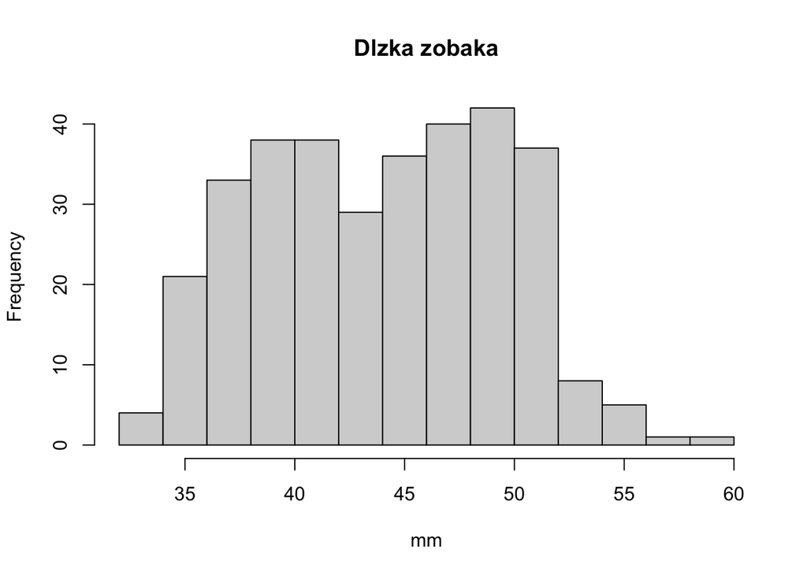

```r
hist(tucniaky$bill_length_mm, main = "Dlzka zobaka", xlab = "mm")
```

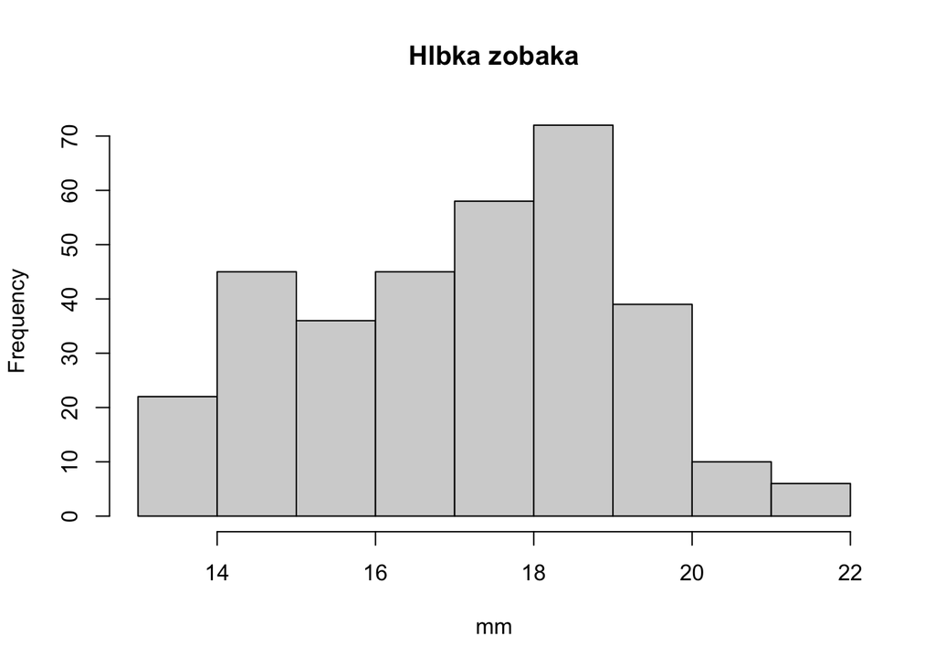

```r
hist(tucniaky$bill_depth_mm, main = "Hlbka zobaka", xlab = "mm")
```

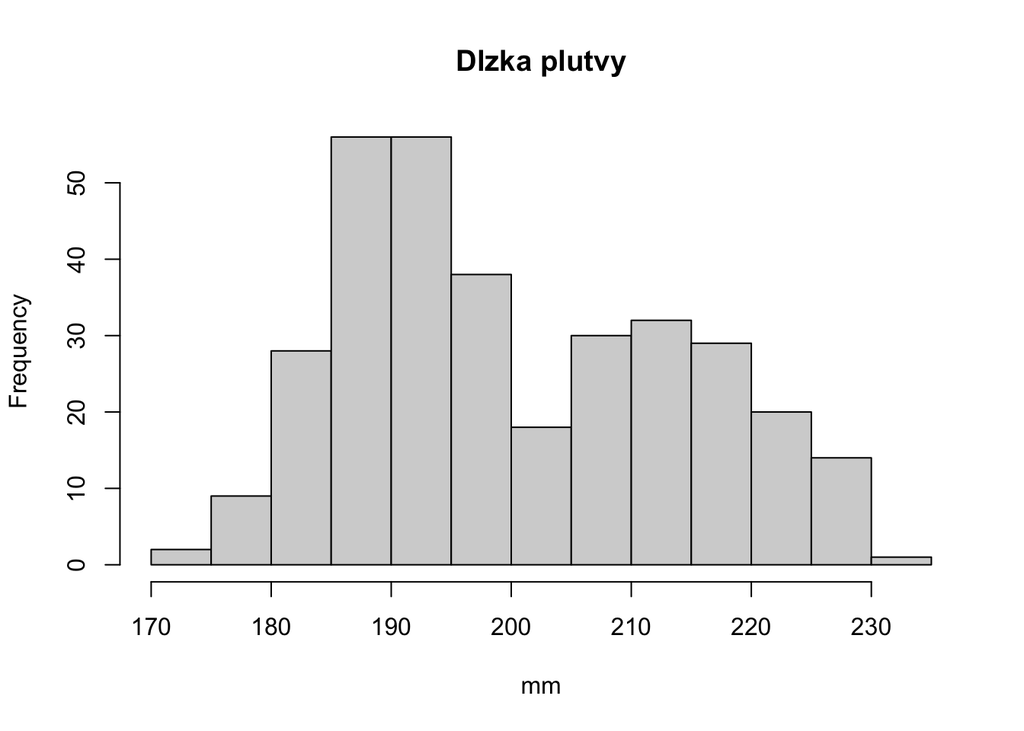

```r
hist(tucniaky$flipper_length_mm, main = "Dlzka plutvy", xlab = "mm")
```

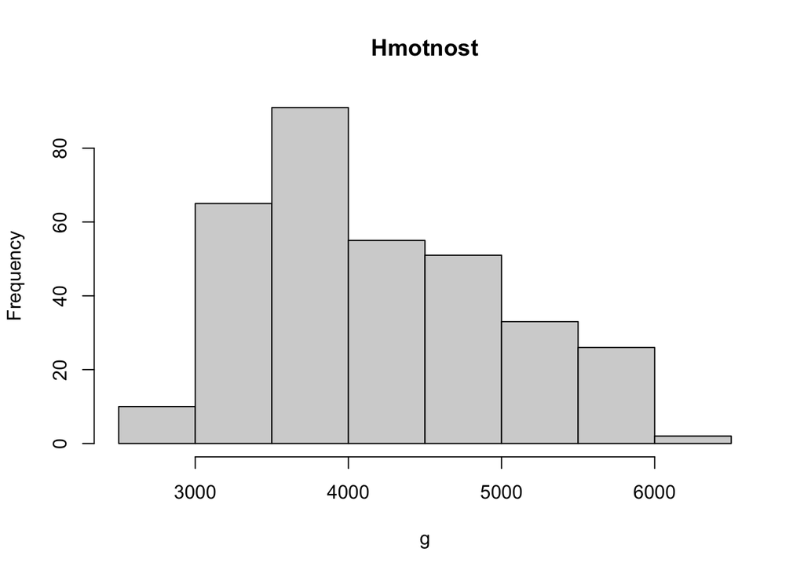

```r
hist(tucniaky$body_mass_g, main = "Hmotnost", xlab = "g")
```

Histogram dlzky plutvy ma dva vrcholy - v datach su zmiesane druhy s roznou velkostou.

# 6. Rozdiely medzi druhmi

```r
tapply(tucniaky$body_mass_g, tucniaky$species, summary)
```

```
## $Adelie
##    Min. 1st Qu.  Median    Mean 3rd Qu.    Max.
##    2850    3362    3700    3706    4000    4775
##
## $Chinstrap
##    Min. 1st Qu.  Median    Mean 3rd Qu.    Max.
##    2700    3488    3700    3733    3950    4800
##
## $Gentoo
##    Min. 1st Qu.  Median    Mean 3rd Qu.    Max.
##    3950    4700    5050    5092    5500    6300
```

```r
tapply(tucniaky$flipper_length_mm, tucniaky$species, mean)
```

```
##    Adelie Chinstrap    Gentoo
##  190.1027  195.8235  217.2353
```

```r
tapply(tucniaky$bill_length_mm, tucniaky$species, mean)
```

```
##    Adelie Chinstrap    Gentoo
##  38.82397  48.83382  47.56807
```

```r
tapply(tucniaky$bill_depth_mm, tucniaky$species, mean)
```

```
##    Adelie Chinstrap    Gentoo
##  18.34726  18.42059  14.99664
```

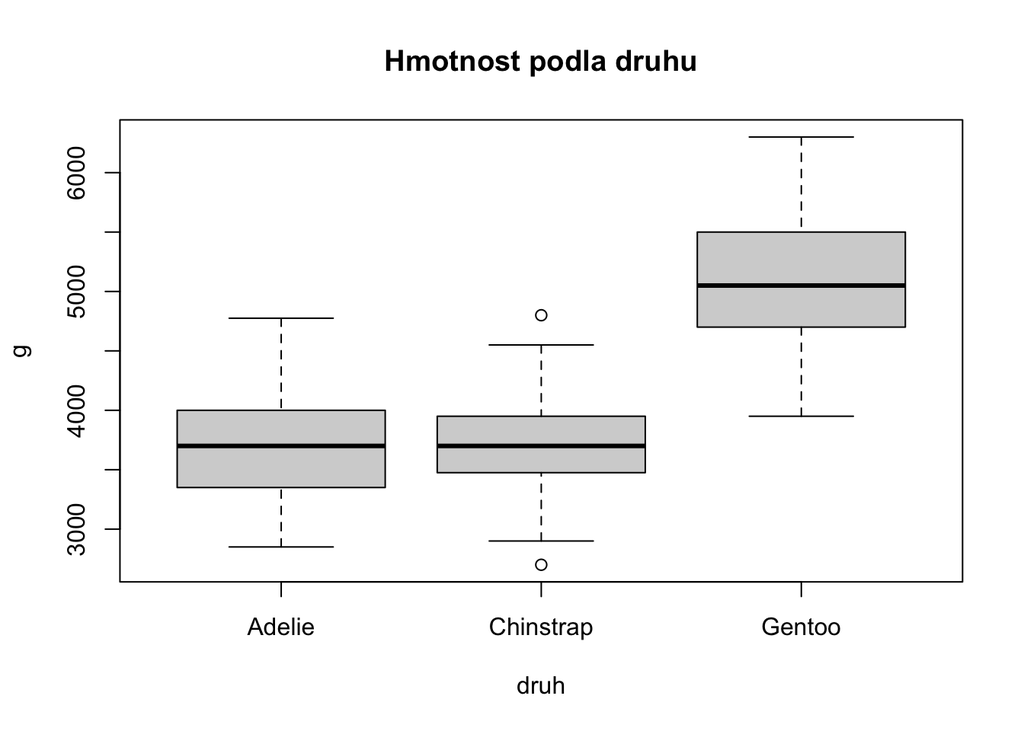

```r
boxplot(tucniaky$body_mass_g ~ tucniaky$species,
        main = "Hmotnost podla druhu", xlab = "druh", ylab = "g")
```

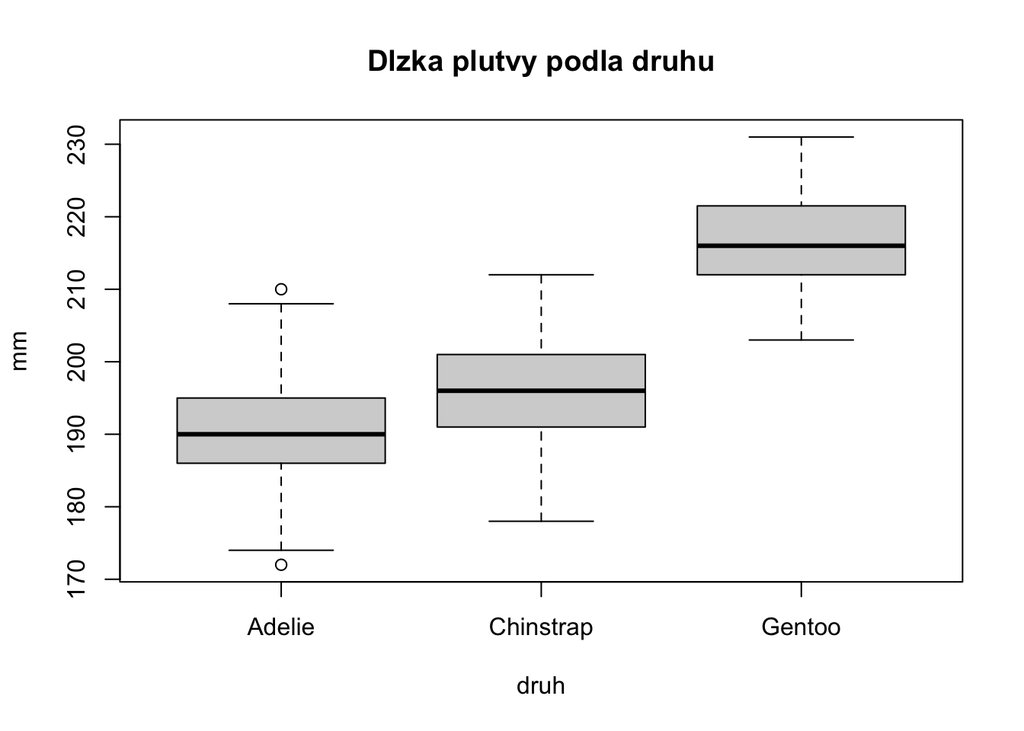

```r
boxplot(tucniaky$flipper_length_mm ~ tucniaky$species,
        main = "Dlzka plutvy podla druhu", xlab = "druh", ylab = "mm")
```

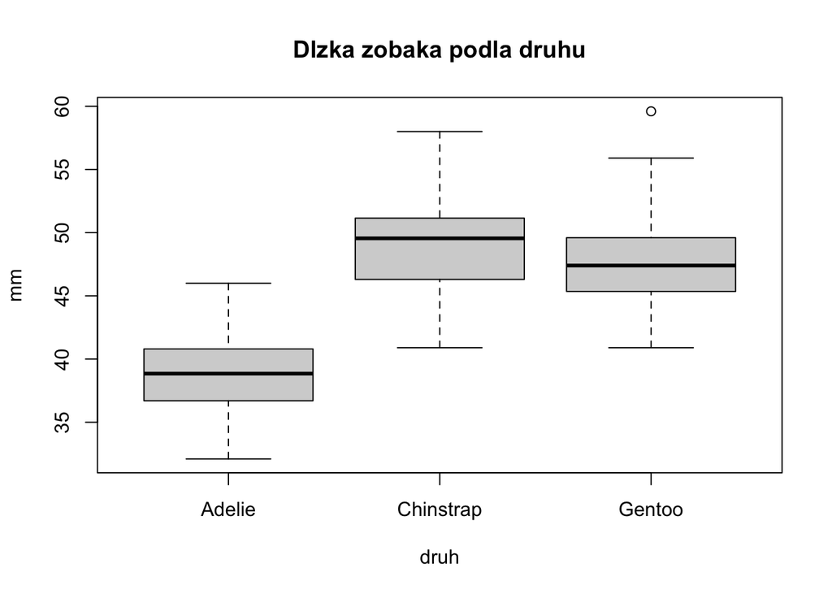

```r
boxplot(tucniaky$bill_length_mm ~ tucniaky$species,
        main = "Dlzka zobaka podla druhu", xlab = "druh", ylab = "mm")
```

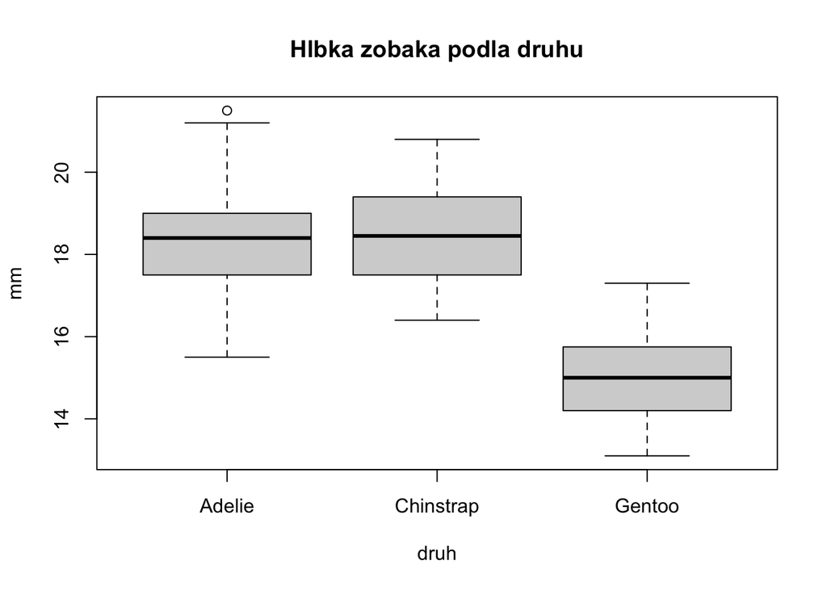

```r
boxplot(tucniaky$bill_depth_mm ~ tucniaky$species,
        main = "Hlbka zobaka podla druhu", xlab = "druh", ylab = "mm")
```

Gentoo je najvacsi (priemer 5092 g, plutva 217 mm), Adelie (3706 g) a Chinstrap (3733 g) vazia skoro rovnako. Gentoo ma ale najplytsi zobak (15 mm). Adelie a Chinstrap sa lisia hlavne dlzkou zobaka (39 mm vs 49 mm).

# 7. Rozdiely medzi pohlaviami

```r
tapply(tucniaky$body_mass_g, tucniaky$sex, mean)
```

```
##   female     male
## 3862.273 4545.685
```

```r
tapply(tucniaky$body_mass_g, list(tucniaky$species, tucniaky$sex), mean)
```

```
##             female     male
## Adelie    3368.836 4043.493
## Chinstrap 3527.206 3938.971
## Gentoo    4679.741 5484.836
```

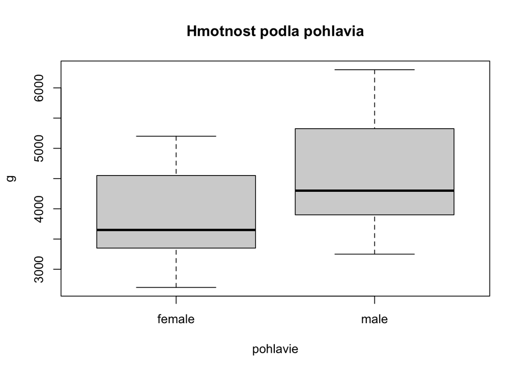

```r
boxplot(tucniaky$body_mass_g ~ tucniaky$sex,
        main = "Hmotnost podla pohlavia", xlab = "pohlavie", ylab = "g")
```

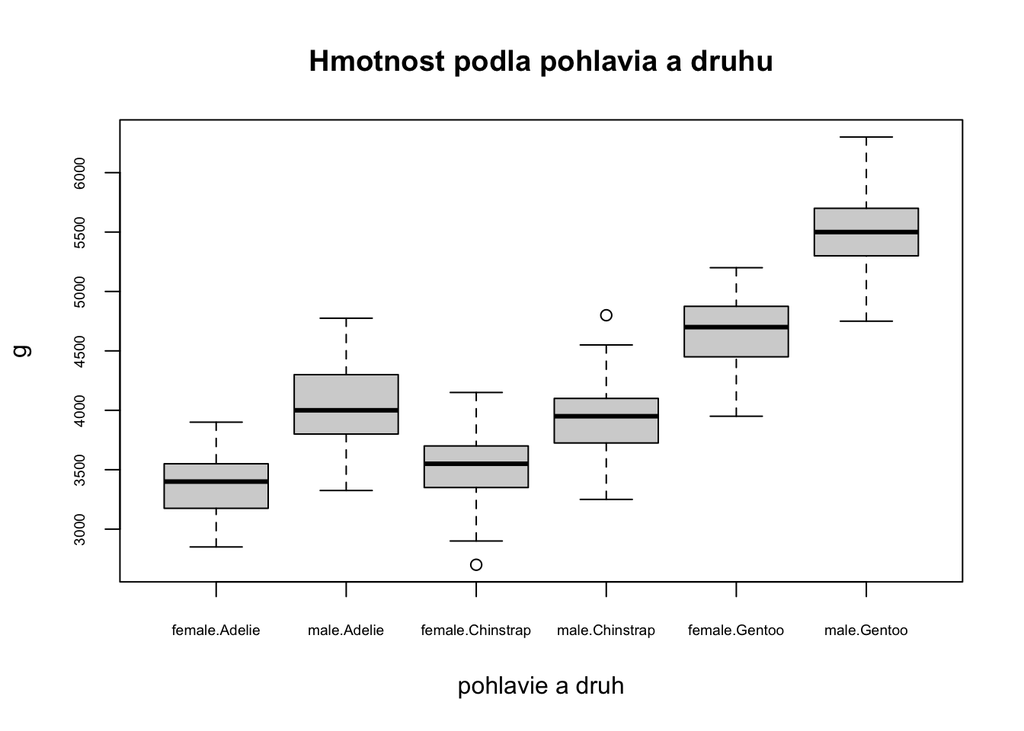

```r
boxplot(tucniaky$body_mass_g ~ tucniaky$sex + tucniaky$species,
        main = "Hmotnost podla pohlavia a druhu",
        xlab = "pohlavie a druh", ylab = "g", cex.axis = 0.6)
```

Samce su tazsie ako samice (4546 g vs 3862 g) a plati to v kazdom druhu zvlast (vidno z tabulky druh x pohlavie aj z boxplotu).

# 8. Vztahy medzi velicinami

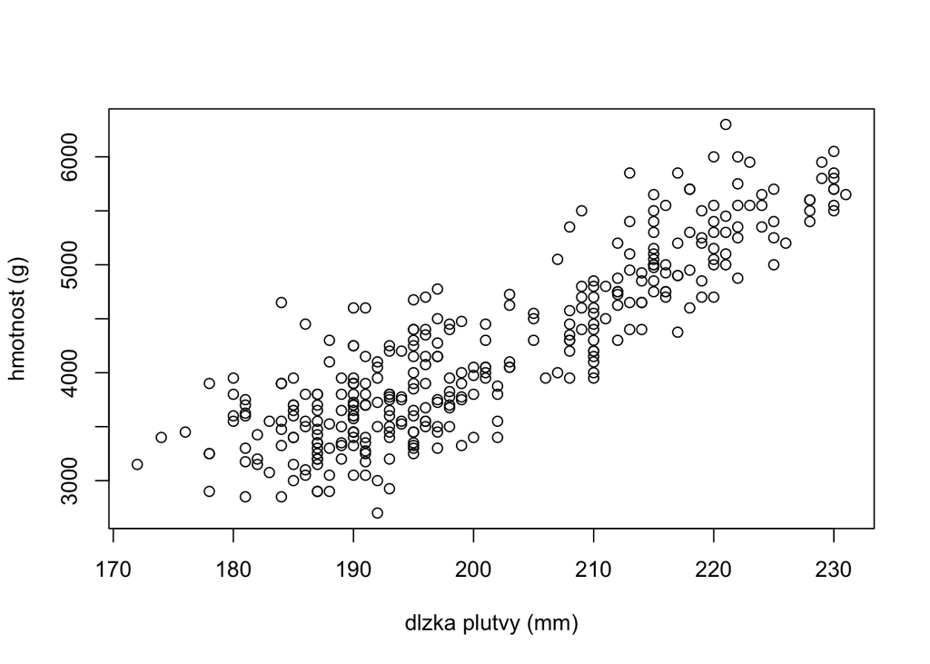

```r
plot(tucniaky$flipper_length_mm, tucniaky$body_mass_g,
     xlab = "dlzka plutvy (mm)", ylab = "hmotnost (g)")
```

```r
cor(tucniaky$flipper_length_mm, tucniaky$body_mass_g)
```

```
## [1] 0.8729789
```

```r
cor(tucniaky$bill_length_mm, tucniaky$body_mass_g)
```

```
## [1] 0.5894511
```

```r
cor(tucniaky$bill_depth_mm, tucniaky$body_mass_g)
```

```
## [1] -0.4720157
```

Dlzka plutvy a hmotnost spolu silno suvisia (korelacia 0.87) - cim dlhsia plutva, tym tazsi tucniak. Dlzka zobaka s hmotnostou suvisi stredne (0.59), hlbka zobaka ma s hmotnostou zapornu korelaciu (-0.47).

Dlzka a hlbka zobaka - najprv vsetci spolu:

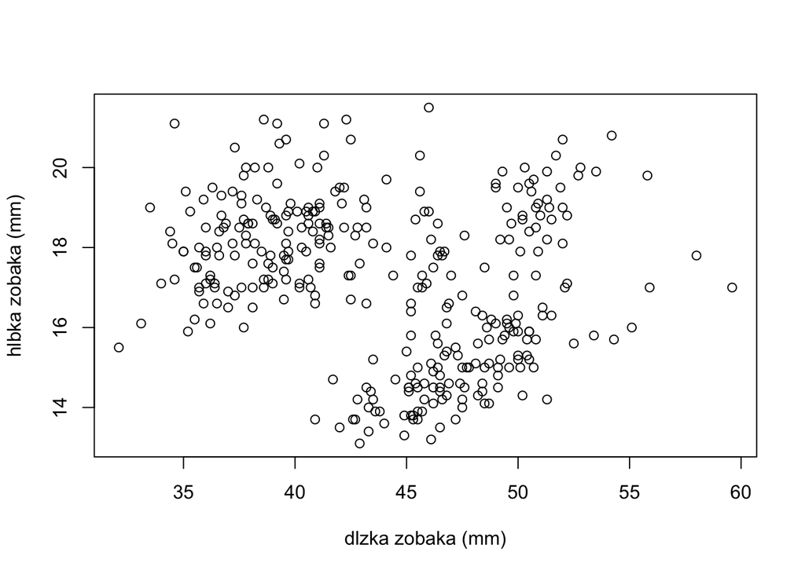

```r
plot(tucniaky$bill_length_mm, tucniaky$bill_depth_mm,
     xlab = "dlzka zobaka (mm)", ylab = "hlbka zobaka (mm)")
```

```r
cor(tucniaky$bill_length_mm, tucniaky$bill_depth_mm)
```

```
## [1] -0.2286256
```

Potom kazdy druh zvlast:

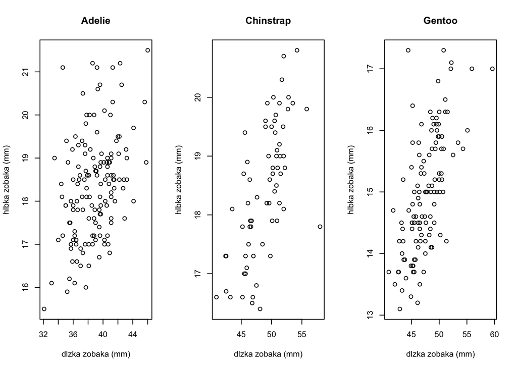

```r
adelie <- tucniaky[tucniaky$species == "Adelie", ]
chinstrap <- tucniaky[tucniaky$species == "Chinstrap", ]
gentoo <- tucniaky[tucniaky$species == "Gentoo", ]

par(mfrow = c(1, 3))
plot(adelie$bill_length_mm, adelie$bill_depth_mm, main = "Adelie",
     xlab = "dlzka zobaka (mm)", ylab = "hlbka zobaka (mm)")
plot(chinstrap$bill_length_mm, chinstrap$bill_depth_mm, main = "Chinstrap",
     xlab = "dlzka zobaka (mm)", ylab = "hlbka zobaka (mm)")
plot(gentoo$bill_length_mm, gentoo$bill_depth_mm, main = "Gentoo",
     xlab = "dlzka zobaka (mm)", ylab = "hlbka zobaka (mm)")
```

```r
par(mfrow = c(1, 1))

cor(adelie$bill_length_mm, adelie$bill_depth_mm)
```

```
## [1] 0.3858132
```

```r
cor(chinstrap$bill_length_mm, chinstrap$bill_depth_mm)
```

```
## [1] 0.6535362
```

```r
cor(gentoo$bill_length_mm, gentoo$bill_depth_mm)
```

```
## [1] 0.6540233
```

Pre vsetkych spolu je korelacia zaporna (-0.23), ale v kazdom druhu zvlast je kladna (Adelie 0.39, Chinstrap 0.65, Gentoo 0.65). Zaporny vysledok vznikol len preto, ze sme zmiesali druhy - preto treba druhy skumat oddelene.

# 9. Zaver

- Po vyhodeni NA mame 333 tucniakov troch druhov, pohlavia su vyvazene.
- Gentoo je vyrazne vacsi ako ostatne dva druhy. Adelie a Chinstrap vazia priblizne rovnako, odlisit ich mozno najma podla dlzky zobaka.
- Samce su v kazdom druhu tazsie ako samice.
- Dlzka plutvy a hmotnost spolu silno kladne suvisia.
- Ked zoberieme vsetky druhy spolu, dlhsi zobak vyzera plytsi. V ramci kazdeho druhu je to ale naopak, preto treba druhy skumat oddelene.